# Churn_analysis

### Importing Libraries

```python
import numpy as np
import pandas as pd
import seaborn as sns
import matplotlib.pyplot as plt
import sqlite3
```

### Import Data

```python
df = pd.read_csv("WA_Fn-UseC_-Telco-Customer-Churn.csv")
```

```python
conn = sqlite3.connect("customer_churn.db")
```

### Initial Data Exploration

```python
df.head(5)
```

|  | customerID | gender | SeniorCitizen | Partner | Dependents | tenure | PhoneService | MultipleLines | InternetService | OnlineSecurity | ... | DeviceProtection | TechSupport | StreamingTV | StreamingMovies | Contract | PaperlessBilling | PaymentMethod | MonthlyCharges | TotalCharges | Churn |
| --- | --- | --- | --- | --- | --- | --- | --- | --- | --- | --- | --- | --- | --- | --- | --- | --- | --- | --- | --- | --- | --- |
| 0 | 7590-VHVEG | Female | 0 | Yes | No | 1 | No | No phone service | DSL | No | ... | No | No | No | No | Month-to-month | Yes | Electronic check | 29.85 | 29.85 | No |
| 1 | 5575-GNVDE | Male | 0 | No | No | 34 | Yes | No | DSL | Yes | ... | Yes | No | No | No | One year | No | Mailed check | 56.95 | 1889.5 | No |
| 2 | 3668-QPYBK | Male | 0 | No | No | 2 | Yes | No | DSL | Yes | ... | No | No | No | No | Month-to-month | Yes | Mailed check | 53.85 | 108.15 | Yes |
| 3 | 7795-CFOCW | Male | 0 | No | No | 45 | No | No phone service | DSL | Yes | ... | Yes | Yes | No | No | One year | No | Bank transfer (automatic) | 42.30 | 1840.75 | No |
| 4 | 9237-HQITU | Female | 0 | No | No | 2 | Yes | No | Fiber optic | No | ... | No | No | No | No | Month-to-month | Yes | Electronic check | 70.70 | 151.65 | Yes |

5 rows × 21 columns

[output not shown]

```python
df.tail(5)
```

|  | customerID | gender | SeniorCitizen | Partner | Dependents | tenure | PhoneService | MultipleLines | InternetService | OnlineSecurity | ... | DeviceProtection | TechSupport | StreamingTV | StreamingMovies | Contract | PaperlessBilling | PaymentMethod | MonthlyCharges | TotalCharges | Churn |
| --- | --- | --- | --- | --- | --- | --- | --- | --- | --- | --- | --- | --- | --- | --- | --- | --- | --- | --- | --- | --- | --- |
| 7038 | 6840-RESVB | Male | 0 | Yes | Yes | 24 | Yes | Yes | DSL | Yes | ... | Yes | Yes | Yes | Yes | One year | Yes | Mailed check | 84.80 | 1990.5 | No |
| 7039 | 2234-XADUH | Female | 0 | Yes | Yes | 72 | Yes | Yes | Fiber optic | No | ... | Yes | No | Yes | Yes | One year | Yes | Credit card (automatic) | 103.20 | 7362.9 | No |
| 7040 | 4801-JZAZL | Female | 0 | Yes | Yes | 11 | No | No phone service | DSL | Yes | ... | No | No | No | No | Month-to-month | Yes | Electronic check | 29.60 | 346.45 | No |
| 7041 | 8361-LTMKD | Male | 1 | Yes | No | 4 | Yes | Yes | Fiber optic | No | ... | No | No | No | No | Month-to-month | Yes | Mailed check | 74.40 | 306.6 | Yes |
| 7042 | 3186-AJIEK | Male | 0 | No | No | 66 | Yes | No | Fiber optic | Yes | ... | Yes | Yes | Yes | Yes | Two year | Yes | Bank transfer (automatic) | 105.65 | 6844.5 | No |

5 rows × 21 columns

```python
df.shape
```

```
(7043, 21)
```

```python
df.info()
```

```
<class 'pandas.core.frame.DataFrame'>
RangeIndex: 7043 entries, 0 to 7042
Data columns (total 21 columns):
 #   Column            Non-Null Count  Dtype
---  ------            --------------  -----
 0   customerID        7043 non-null   object
 1   gender            7043 non-null   object
 2   SeniorCitizen     7043 non-null   int64
 3   Partner           7043 non-null   object
 4   Dependents        7043 non-null   object
 5   tenure            7043 non-null   int64
 6   PhoneService      7043 non-null   object
 7   MultipleLines     7043 non-null   object
 8   InternetService   7043 non-null   object
 9   OnlineSecurity    7043 non-null   object
 10  OnlineBackup      7043 non-null   object
 11  DeviceProtection  7043 non-null   object
 12  TechSupport       7043 non-null   object
 13  StreamingTV       7043 non-null   object
 14  StreamingMovies   7043 non-null   object
 15  Contract          7043 non-null   object
 16  PaperlessBilling  7043 non-null   object
 17  PaymentMethod     7043 non-null   object
 18  MonthlyCharges    7043 non-null   float64
 19  TotalCharges      7043 non-null   object
 20  Churn             7043 non-null   object
dtypes: float64(1), int64(2), object(18)
memory usage: 1.1+ MB
```

### Data Cleaning

```python
# Checking Missing Values

df.isnull().sum()
```

```
customerID          0
gender              0
SeniorCitizen       0
Partner             0
Dependents          0
tenure              0
PhoneService        0
MultipleLines       0
InternetService     0
OnlineSecurity      0
OnlineBackup        0
DeviceProtection    0
TechSupport         0
StreamingTV         0
StreamingMovies     0
Contract            0
PaperlessBilling    0
PaymentMethod       0
MonthlyCharges      0
TotalCharges        0
Churn               0
dtype: int64
```

```python
# Checking duplicates Records

df.duplicated().sum()
```

```
np.int64(0)
```

```python
# Checking Blank Values in TotalCharges

(df['TotalCharges'] == " ").sum()
```

```
np.int64(11)
```

```python
df['TotalCharges'] = df['TotalCharges'].replace(" ", pd.NA)
```

```python
df['TotalCharges'] = pd.to_numeric(df['TotalCharges'])
```

```python
df.info()
```

```
<class 'pandas.core.frame.DataFrame'>
RangeIndex: 7043 entries, 0 to 7042
Data columns (total 21 columns):
 #   Column            Non-Null Count  Dtype
---  ------            --------------  -----
 0   customerID        7043 non-null   object
 1   gender            7043 non-null   object
 2   SeniorCitizen     7043 non-null   int64
 3   Partner           7043 non-null   object
 4   Dependents        7043 non-null   object
 5   tenure            7043 non-null   int64
 6   PhoneService      7043 non-null   object
 7   MultipleLines     7043 non-null   object
 8   InternetService   7043 non-null   object
 9   OnlineSecurity    7043 non-null   object
 10  OnlineBackup      7043 non-null   object
 11  DeviceProtection  7043 non-null   object
 12  TechSupport       7043 non-null   object
 13  StreamingTV       7043 non-null   object
 14  StreamingMovies   7043 non-null   object
 15  Contract          7043 non-null   object
 16  PaperlessBilling  7043 non-null   object
 17  PaymentMethod     7043 non-null   object
 18  MonthlyCharges    7043 non-null   float64
 19  TotalCharges      7032 non-null   float64
 20  Churn             7043 non-null   object
dtypes: float64(2), int64(2), object(17)
memory usage: 1.1+ MB
```

### Handling Missing Values

```python
df.isnull().sum()
```

```
customerID           0
gender               0
SeniorCitizen        0
Partner              0
Dependents           0
tenure               0
PhoneService         0
MultipleLines        0
InternetService      0
OnlineSecurity       0
OnlineBackup         0
DeviceProtection     0
TechSupport          0
StreamingTV          0
StreamingMovies      0
Contract             0
PaperlessBilling     0
PaymentMethod        0
MonthlyCharges       0
TotalCharges        11
Churn                0
dtype: int64
```

```python
df.dropna(inplace=True)
```

```python
df.isnull().sum()
```

```
customerID          0
gender              0
SeniorCitizen       0
Partner             0
Dependents          0
tenure              0
PhoneService        0
MultipleLines       0
InternetService     0
OnlineSecurity      0
OnlineBackup        0
DeviceProtection    0
TechSupport         0
StreamingTV         0
StreamingMovies     0
Contract            0
PaperlessBilling    0
PaymentMethod       0
MonthlyCharges      0
TotalCharges        0
Churn               0
dtype: int64
```

# Exploratory Data Analysis (EDA)

### 1. Customer Churn Distribution

```python
df['Churn'].value_counts()
```

```
Churn
No     5163
Yes    1869
Name: count, dtype: int64
```

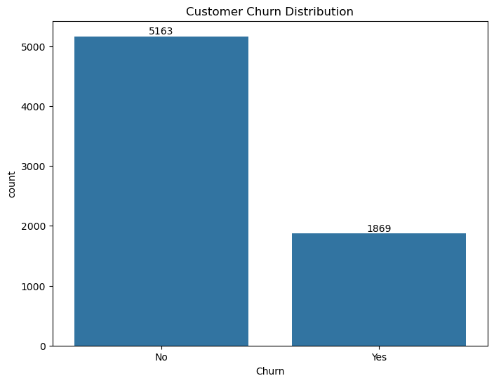

```python
plt.figure(figsize=(8,6))
ax = sns.countplot(x='Churn', data=df)

for container in ax.containers:
    ax.bar_label(container)

plt.title("Customer Churn Distribution")
plt.show()
```

### Observation

- Out of 7,032 customers, 5,163 customers stayed with the company while 1,869 customers churned. This indicates that the majority of customers were retained, but approximately 27% of customers left the company, making churn a significant business concern.

### Business Insight

- Since nearly one out of every four customers churned, the company should identify the factors influencing customer attrition and develop retention strategies to improve customer loyalty.

### 2. Gender vs Customer Churn

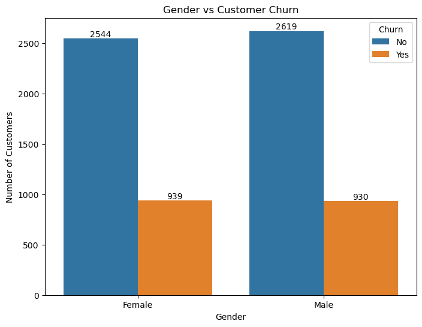

```python
plt.figure(figsize=(8,6))
ax = sns.countplot(x='gender', data=df, hue='Churn')

for container in ax.containers:
    ax.bar_label(container)

plt.title("Gender vs Customer Churn")
plt.xlabel("Gender")
plt.ylabel("Number of Customers")
plt.show()
```

### Observation

- The number of male and female customers in the dataset is almost equal. The churn count is also very similar for both genders, with 939 female customers and 930 male customers leaving the company.

### Business Insight

- Gender does not appear to have a significant impact on customer churn, as both male and female customers show nearly identical churn patterns. Other factors such as contract type, tenure, monthly charges, or payment method are likely to have a greater influence on customer churn.

### 3. Contract Type vs Customer Churn

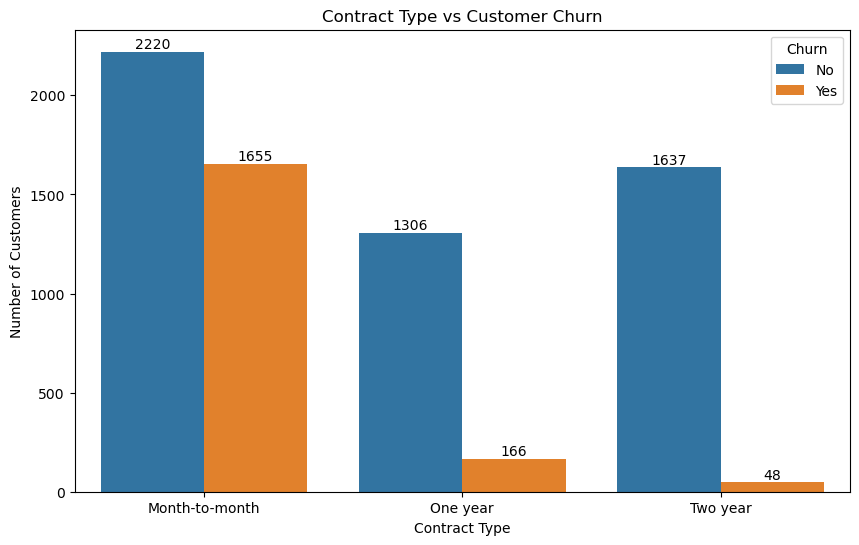

```python
plt.figure(figsize=(10,6))

ax = sns.countplot(x='Contract', data=df, hue='Churn')

for container in ax.containers:
    ax.bar_label(container)

plt.title("Contract Type vs Customer Churn")
plt.xlabel("Contract Type")
plt.ylabel("Number of Customers")
plt.show()
```

### Observation

- Customers with month-to-month contracts have the highest number of churn cases (1,655). In contrast, customers with one-year and two-year contracts have significantly lower churn counts (166 and 48 respectively).

### Business Insight

- Contract type is a major factor influencing customer churn. Customers on month-to-month contracts are much more likely to leave the company than those on longer-term contracts. Encouraging customers to switch to one-year or two-year contracts could help improve customer retention and reduce churn.

### 4. Tenure vs Customer Churn

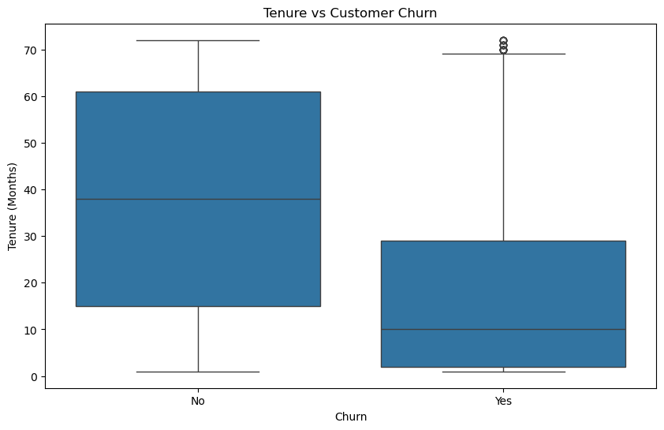

```python
plt.figure(figsize=(10,6))

sns.boxplot(x='Churn', y='tenure', data=df)

plt.title("Tenure vs Customer Churn")
plt.xlabel("Churn")
plt.ylabel("Tenure (Months)")
plt.show()
```

### Observation

- Customers who churned generally have a much lower tenure than customers who stayed. The median tenure for churned customers is around 9–10 months, whereas customers who remained with the company have a median tenure of approximately 38 months.

### Business Insight

- Tenure is a strong indicator of customer churn. Customers are more likely to leave during the early months of their subscription. Improving the onboarding experience and engaging customers during their first year may help reduce churn.

### 5. Monthly Charges vs Customer Churn

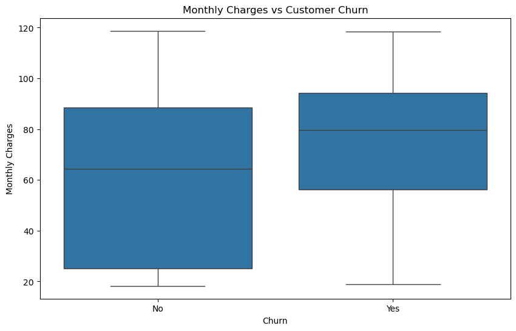

```python
plt.figure(figsize=(10,6))

sns.boxplot(x='Churn', y='MonthlyCharges', data=df)

plt.title("Monthly Charges vs Customer Churn")
plt.xlabel("Churn")
plt.ylabel("Monthly Charges")
plt.show()
```

### Observation

- The median monthly charge for customers who churned is higher than for customers who stayed. This indicates that churned customers generally pay higher monthly charges.

### Business Insight

- Monthly charges appear to be an important factor influencing customer churn. Customers with higher monthly charges are more likely to leave the company. The company could consider reviewing pricing plans, offering discounts, or providing additional value to improve customer retention.

### 6. Payment Method vs Customer Churn

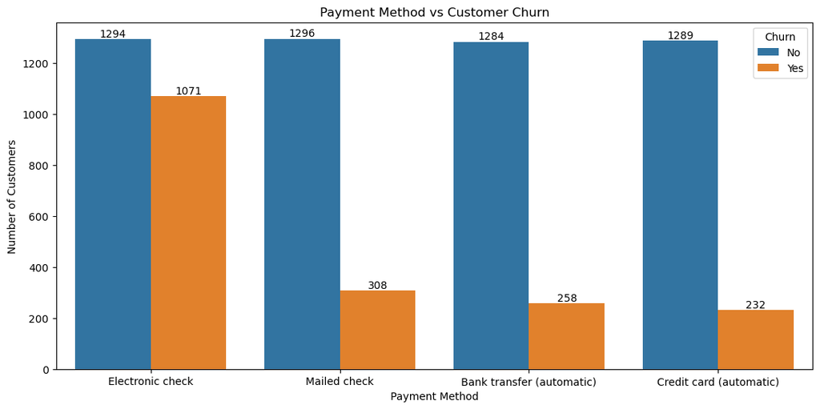

```python
plt.figure(figsize=(13,6))

ax = sns.countplot(x='PaymentMethod', data=df, hue='Churn')

for container in ax.containers:
    ax.bar_label(container)

plt.title("Payment Method vs Customer Churn")
plt.xlabel("Payment Method")
plt.ylabel("Number of Customers")
plt.show()
```

### Observation

- Customers using Electronic Check have the highest number of churn cases (1,071), whereas customers using Mailed Check, Bank Transfer (Automatic), and Credit Card (Automatic) have considerably fewer churn cases.

### Business Insight

- Payment method appears to influence customer churn. Customers using Electronic Check are more likely to leave the company than customers using automatic payment methods. Encouraging customers to switch to automatic payment options may help improve customer retention.

### 7. Internet Service vs Customer Churn

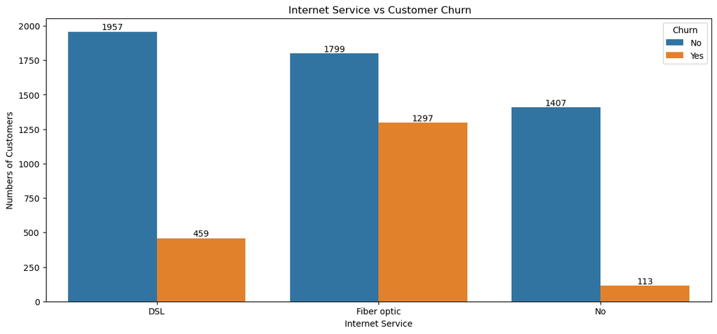

```python
plt.figure(figsize=(14,6))

ax = sns.countplot(x='InternetService', data=df, hue='Churn')

for container in ax.containers:
    ax.bar_label(container)

plt.title(" Internet Service vs Customer Churn")
plt.xlabel("Internet Service")
plt.ylabel("Numbers of Customers")
plt.show()
```

### Observation

- Customers using Fiber optic internet service have the highest number of churn cases (1,297). In comparison, customers using DSL and those without internet service show considerably lower churn.

### Business Insight

- Internet service type appears to influence customer churn. Fiber optic customers are more likely to churn than DSL customers. The company should investigate factors such as pricing, service quality, or customer satisfaction among Fiber optic users to improve retention.

### 8. Senior Citizen vs Customer Churn.

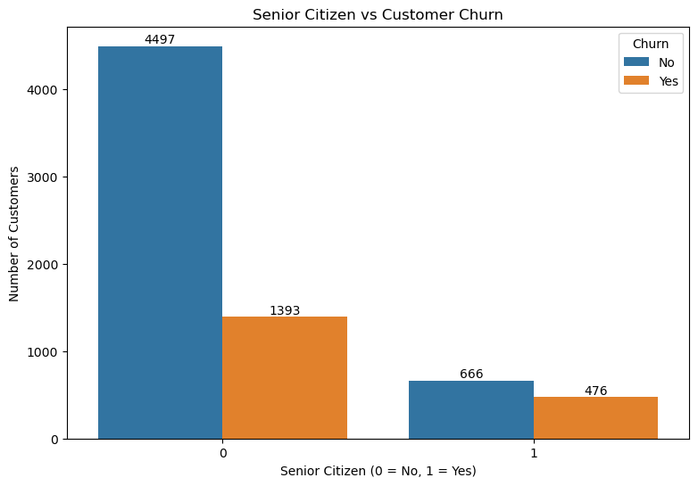

```python
plt.figure(figsize=(9,6))

ax = sns.countplot(x='SeniorCitizen', data=df, hue='Churn')

for container in ax.containers:
    ax.bar_label(container)

plt.title("Senior Citizen vs Customer Churn")
plt.xlabel("Senior Citizen (0 = No, 1 = Yes)")
plt.ylabel("Number of Customers")
plt.show()
```

### Observation

- Non-senior citizens make up the majority of customers in the dataset. However, among senior citizens, the number of churned customers is relatively high compared to the number who stayed, indicating a higher likelihood of churn.

### Business Insight

- Senior citizens appear to have a higher tendency to churn compared to non-senior citizens. The company could improve retention by offering personalized support, special discounts, or service plans tailored to senior customers.

### 9. Partner vs Customer Churn

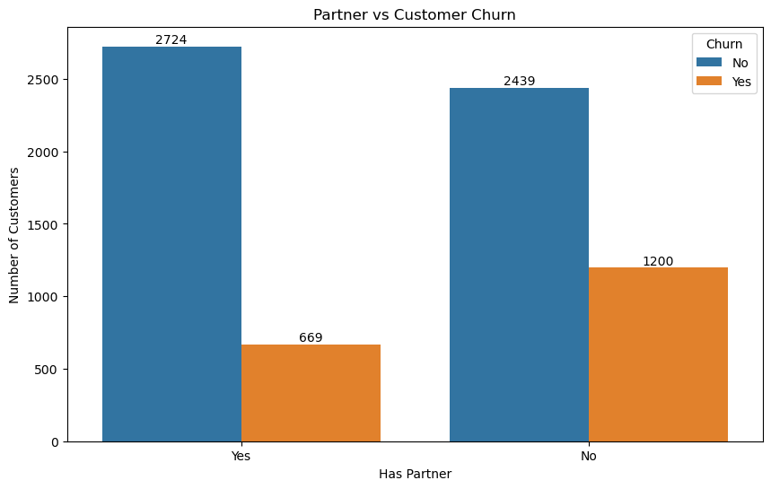

```python
plt.figure(figsize=(10,6))

ax = sns.countplot(x='Partner', data=df, hue='Churn')

for container in ax.containers:
    ax.bar_label(container)

plt.title("Partner vs Customer Churn")
plt.xlabel("Has Partner")
plt.ylabel("Number of Customers")
plt.show()
```

### Observation

- Customers without a partner have a significantly higher number of churn cases (1,200) compared to customers with a partner (669). Customers with a partner are more likely to remain with the company.

### Business Insight

- Partner status appears to influence customer churn. Customers without a partner are more likely to leave the company. The company could consider targeted retention campaigns or personalized offers for customers who do not have a partner.

### 10. Correlation Heatmap

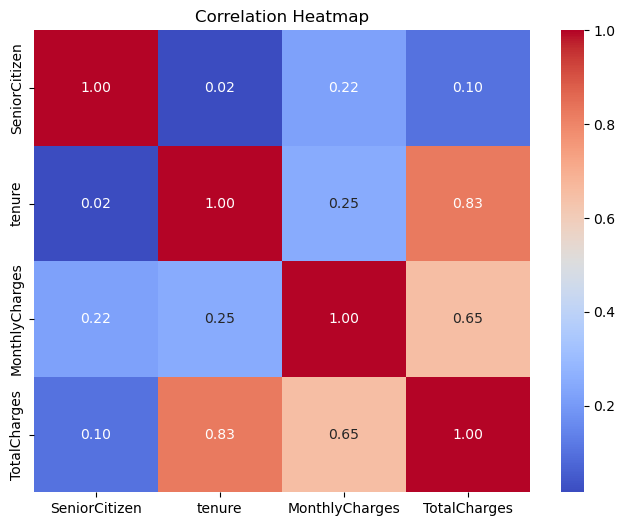

```python
plt.figure(figsize=(8,6))

sns.heatmap(
    df[['SeniorCitizen', 'tenure', 'MonthlyCharges', 'TotalCharges']].corr(),
    annot=True,
    cmap='coolwarm',
    fmt='.2f'
)

plt.title("Correlation Heatmap")
plt.show()
```

### Observation

- The heatmap shows the correlation between the numerical features in the dataset. Tenure and TotalCharges have a strong positive correlation (0.83), indicating that customers who stay longer tend to accumulate higher total charges. MonthlyCharges and TotalCharges also show a moderate positive correlation (0.65). SeniorCitizen has only weak correlations with the other numerical variables.

### Business Insight

- The strongest relationship is between Tenure and TotalCharges, which is expected because customers who remain with the company for a longer time naturally accumulate higher total charges. No strong relationship exists between SeniorCitizen and the other numerical features.

```python
df.to_sql('customers', conn, if_exists='replace', index=False)
```

```
7032
```

```python
df.to_csv("/Users/riya/Desktop/cleaned_churn.csv", index=False)
```